# 課題4 解答：random coefficient logit の推定と合併分析

計量経済学II

作者

Kei Ikegami

この解答は**そのまま最後まで実行できる完全版**である。各問について「なぜこう書くか」「どこで間違えやすいか」「部分点の基準」を添える。数値は環境により末尾がわずかに揺れうるが、結論（$\sigma$ の argmin が 0.8、mc 逆算が一致、合併で当事者価格が上昇）は再現する。

# Part 1：市場データを自作する

## 問1・問2：DGP とシェア生成

内生価格の作り方（$\xi$ に反応するマークアップ）と、$\delta$ を与えるとシェアを返す関数がこの回の土台だ。個人偏差 $\mu_{ij} = -(\alpha_i - \bar\alpha^{\text{lvl}})p_j$ を `outer()` で作るのがコツ。

```r
# 次元と真のパラメータ
J <- 3; T <- 60; ns <- 200
beta0_true  <- 4.0
beta_x_true <- 1.5
abar_true   <- 0.5
sigma_true  <- 0.8
alpha_bar_true <- exp(abar_true)

# 外生変数・費用・内生価格
x  <- matrix(rnorm(T * J), T, J)
w  <- matrix(runif(T * J, 0.3, 1.3), T, J)
xi <- matrix(rnorm(T * J, 0, 0.6), T, J)
g0 <- 0.2; gx <- 0.2; gw <- 1.0
omega <- matrix(rnorm(T * J, 0, 0.1), T, J)
mc <- exp(g0 + gx * x + gw * w + omega)
price <- mc * 1.4 + 0.8 * pmax(xi, 0) + 0.1     # xi に反応 -> 内生
nu_p <- rnorm(ns)

# delta を与えるとシェアを返す関数
shares_from_delta <- function(delta_t, p_t, abar, sigma, nu_p) {
  alpha_i  <- exp(abar + sigma * nu_p)
  abar_lvl <- exp(abar)
  mu <- -outer(alpha_i - abar_lvl, p_t)          # (ns x J)
  V  <- sweep(mu, 2, delta_t, "+")
  eV <- exp(V)
  denom <- 1 + rowSums(eV)
  colMeans(eV / denom)
}

# 観測シェア（真値で生成）
delta_true <- beta0_true + beta_x_true * x - alpha_bar_true * price + xi
S_obs <- matrix(0, T, J)
for (t in 1:T) {
  S_obs[t, ] <- shares_from_delta(delta_true[t, ], price[t, ], abar_true, sigma_true, nu_p)
}
S0_obs <- 1 - rowSums(S_obs)
```

**ノート部分点の基準（問1・問2）**

- **問1（15点）**：`x`・`w`・`xi`・`mc`・`price` が正しい分布・式で生成されていれば満点。価格に `xi` が入っていない（＝内生性を作っていない）と −8点。
- **問2（15点）**：`shares_from_delta` が動き、`mu` の符号（マイナス）と `outer` の使い方が正しければ満点。`denom` に `1 +`（outside）を忘れると −6点。`colMeans`（個人平均）を忘れて個人シェアのまま返すと −6点。

## 問3：記述統計と内生性の確認

```r
cat("インサイドシェアの範囲:", round(range(S_obs), 4), "\n")
```

```
インサイドシェアの範囲: 0.0008 0.4399
```

```r
cat("アウトサイドシェアの範囲:", round(range(S0_obs), 4), "\n")
```

```
アウトサイドシェアの範囲: 0.4897 0.8254
```

```r
cat("価格とxiの相関（財ごと）:",
    round(sapply(1:J, function(j) cor(price[, j], xi[, j])), 3), "\n")
```

```
価格とxiの相関（財ごと）: 0.138 0.309 0.232
```

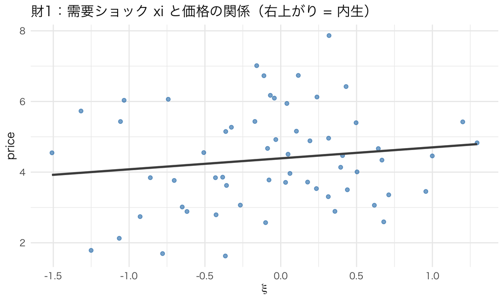

```r
df_endog <- data.frame(price = price[, 1], xi = xi[, 1])
ggplot(df_endog, aes(xi, price)) +
  geom_point(alpha = 0.6, color = "#1f77b4") +
  geom_smooth(method = "lm", se = FALSE, color = "grey30") +
  labs(title = "財1：需要ショック xi と価格の関係（右上がり = 内生）",
       x = expression(xi), y = "price")
```

価格と $\xi$ に正の相関（マークアップが $\xi$ に反応する設計の帰結）が見える。これが「素朴なOLSでは価格係数を過小推定する」原因であり、IV が必要な理由だ。

**ノート部分点の基準（問3、10点）**

シェア範囲・相関の出力（各3点）と、内生性を示す図（4点）。相関がゼロ近傍になってしまっている場合は問1の価格生成を疑うよう促す。

# Part 2：推定と合併分析

## 問4：縮小写像で $\delta$ を解く

穴埋めの答え：初期値は `log(S_obs) - log(S0_obs)`、更新式は `d + log(S_obs[t,]) - log(s_pred)`。

```r
solve_delta <- function(sigma, abar, S_obs, S0_obs, price, nu_p,
                        tol = 1e-11, maxit = 1000, trace_t = NULL) {
  Tn <- nrow(S_obs); Jn <- ncol(S_obs)
  delta <- log(S_obs) - log(S0_obs)              # plain-logit 初期値（Berry 反転）
  trace <- NULL
  for (t in 1:Tn) {
    d <- delta[t, ]
    errs <- numeric(0)
    for (it in 1:maxit) {
      s_pred <- shares_from_delta(d, price[t, ], abar, sigma, nu_p)
      d_new  <- d + log(S_obs[t, ]) - log(s_pred)   # 縮小写像
      err    <- max(abs(d_new - d))
      errs   <- c(errs, err)
      d <- d_new
      if (err < tol) break
    }
    delta[t, ] <- d
    if (!is.null(trace_t) && t == trace_t) trace <- errs
  }
  list(delta = delta, trace = trace)
}

res_true <- solve_delta(sigma_true, abar_true, S_obs, S0_obs, price, nu_p, trace_t = 1)

recon_err <- max(abs(sapply(1:T, function(t)
  shares_from_delta(res_true$delta[t, ], price[t, ], abar_true, sigma_true, nu_p) - S_obs[t, ])))
cat("シェア再現の最大誤差:", recon_err, "\n")
```

```
シェア再現の最大誤差: 0.000000000003134104
```

```r
cat("delta 回収の最大誤差（真値との差）:", max(abs(res_true$delta - delta_true)), "\n")
```

```
delta 回収の最大誤差（真値との差）: 0.00000000006712808
```

```r
cat("市場1の収束反復数:", length(res_true$trace), "\n")
```

```
市場1の収束反復数: 103
```

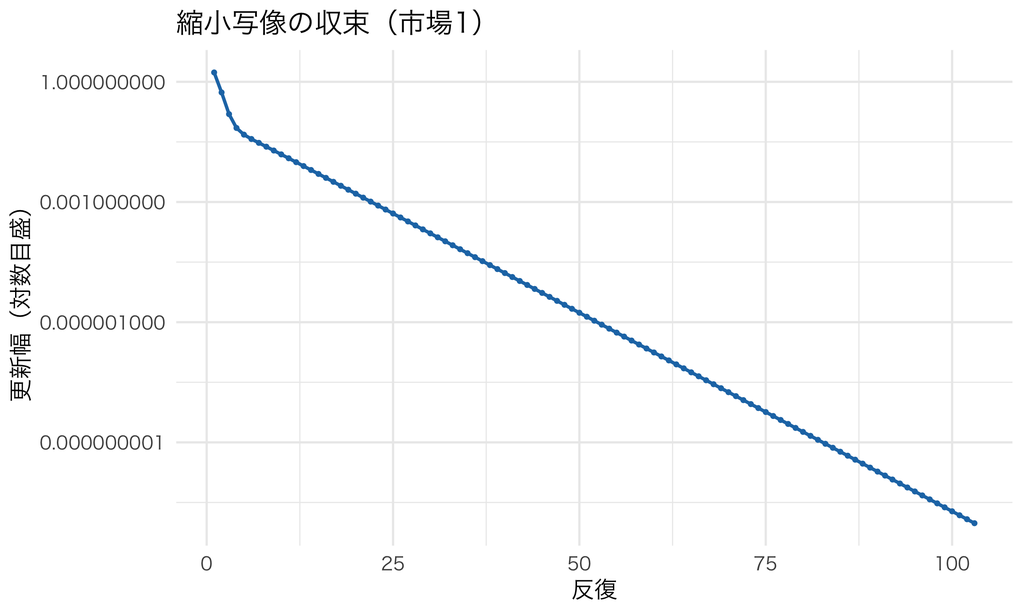

縮小写像の収束（市場1）。誤差が対数目盛でほぼ直線に落ちる = 幾何収束。

```r
df_trace <- data.frame(iter = seq_along(res_true$trace), err = res_true$trace)
ggplot(df_trace, aes(iter, err)) +
  geom_line(color = "#1f77b4", linewidth = 0.9) + geom_point(size = 0.8, color = "#1f77b4") +
  scale_y_log10() +
  labs(title = "縮小写像の収束（市場1）", x = "反復", y = "更新幅（対数目盛）")
```

**ノート部分点の基準（問4、15点）**

初期値（4点）・更新式（6点）が正しく、収束して観測シェアを再現できれば満点。収束プロット（3点）、再現誤差の報告（2点）。`log(s_pred)` で `NaN` が出て発散している場合は、初期値か `outer` の符号を見直すよう指示。

## 問5：GMM 目的関数を $\sigma$ のグリッドで評価する

穴埋めの答え：$\theta_1 = (X'ZWZ'X)^{-1}X'ZWZ'\delta$、$Q = g'Wg$。**$\delta$ と $X$ の並び順を一致させる**のが最重要。

```r
build_Z <- function(x, w) {
  Tn <- nrow(x); Jn <- ncol(x)
  Z <- matrix(0, Tn * Jn, 5)
  row <- 1
  for (t in 1:Tn) for (j in 1:Jn) {
    others <- setdiff(1:Jn, j)
    Z[row, ] <- c(1, x[t, j], w[t, j], sum(x[t, others]), sum(w[t, others]))
    row <- row + 1
  }
  Z
}
build_X <- function(x, price) cbind(1, as.vector(t(x)), as.vector(t(price)))

Z    <- build_Z(x, w)
Xmat <- build_X(x, price)

gmm_step <- function(sigma, abar) {
  res <- solve_delta(sigma, abar, S_obs, S0_obs, price, nu_p)
  d <- as.vector(t(res$delta))                    # t() で Z・X と同じ行優先に
  W  <- solve(crossprod(Z))
  ZX <- crossprod(Z, Xmat)
  Zd <- crossprod(Z, d)
  theta1 <- solve(t(ZX) %*% W %*% ZX, t(ZX) %*% W %*% Zd)   # IV-GMM
  xi_hat <- d - Xmat %*% theta1
  g <- crossprod(Z, xi_hat)
  Q <- as.numeric(t(g) %*% W %*% g)
  list(Q = Q, theta1 = as.vector(theta1), xi_hat = xi_hat)
}

sigma_grid <- c(0.0, 0.4, 0.8, 1.2)
Q_vals <- sapply(sigma_grid, function(s) gmm_step(s, abar_true)$Q)
df_Q <- data.frame(sigma = sigma_grid, Q = round(Q_vals, 4))
kable(df_Q, caption = "GMM目的関数 Q(sigma)")
```

GMM目的関数 Q(sigma)

| sigma | Q |
| --- | --- |
| 0.0 | 29.9939 |
| 0.4 | 10.2301 |
| 0.8 | 0.1776 |
| 1.2 | 3.6778 |

```r
cat("argmin:", sigma_grid[which.min(Q_vals)], "（真値 0.8）\n")
```

```
argmin: 0.8 （真値 0.8）
```

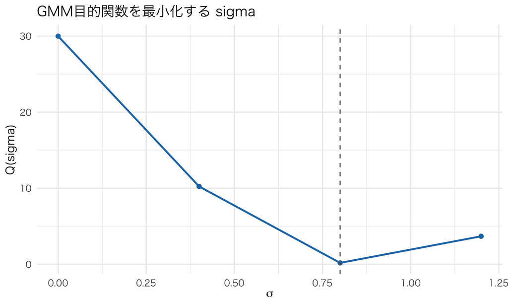

GMM目的関数。真値 0.8 で最小になる。

```r
ggplot(df_Q, aes(sigma, Q)) +
  geom_line(color = "#1f77b4", linewidth = 1) + geom_point(size = 2, color = "#1f77b4") +
  geom_vline(xintercept = 0.8, linetype = "dashed", color = "grey40") +
  labs(title = "GMM目的関数を最小化する sigma", x = expression(sigma), y = "Q(sigma)")
```

```r
best_sigma <- sigma_grid[which.min(Q_vals)]
fit_best <- gmm_step(best_sigma, abar_true)
data.frame(
  parameter = c("定数(beta0)", "beta_x", "-alpha_bar(価格)"),
  estimated = round(fit_best$theta1, 3),
  truth     = round(c(beta0_true, beta_x_true, -alpha_bar_true), 3)
) |> kable(caption = "回収された線形パラメータ vs 真値")
```

回収された線形パラメータ vs 真値

| parameter | estimated | truth |
| --- | --- | --- |
| 定数(beta0) | 3.896 | 4.000 |
| beta_x | 1.497 | 1.500 |
| -alpha_bar(価格) | -1.621 | -1.649 |

**ノート部分点の基準（問5、15点）**

`theta1` の式（5点）・`Q` の式（3点）・グリッド評価と argmin=0.8 の確認（4点）・線形パラメータの回収表（3点）。**`as.vector(t(res$delta))` の `t()` を忘れて argmin がずれている**場合は、並び順のバグとして大きく減点（−8点）し、下記の warning を参照させる。

**警告ここで最も多い失敗：delta と X の並び順**

`build_Z`・`build_X` は「市場 t を固定して財 j を回す」＝**行優先**で製品を並べている。一方 `res$delta` は `T x J` 行列で、`as.vector()`（列優先）すると順序が変わる。だから `as.vector(t(res$delta))` と `t()` を入れて行優先に揃える。ここがズレると、$\delta_{jt}$ が別の製品の $x_{kt}$・$p_{kt}$ と対応づけられ、推定値が真値から大きく外れる（$\sigma$ の谷が消える／ずれる）。デバッグのコツ：`head(cbind(d, Xmat))` を目視し、$\delta$ が大きい財の価格が本当に高いか等、対応の妥当性を確認する。

## 問6：plain logit と $\hat\sigma$ で弾力性を比較する

**重要自己弾力性は「価格の関数として delta を作り直して」から微分する**

ここが問6の勘所であり、最も間違えやすい点だ。$\delta_{jt} = \text{const} + \beta_x x_{jt} + (\text{価格係数})\,p_{jt} + \hat\xi_{jt}$ には**価格が入っている**。だから価格を微小変化させたら、シェアは (1) $\delta$ を通じた効果（平均価格係数）と (2) 個人偏差 $\mu$ を通じた効果（異質性）の**両方**で動く。$\delta$ を固定したまま $\mu$ の中の $p$ だけ動かすと、$\sigma=0$ のとき弾力性がゼロになってしまう（$\mu$ が $p$ に依存しなくなるから）という誤りに陥る。必ず「$\delta$ を価格の関数として作り直す」`delta_of_p` を使うこと。

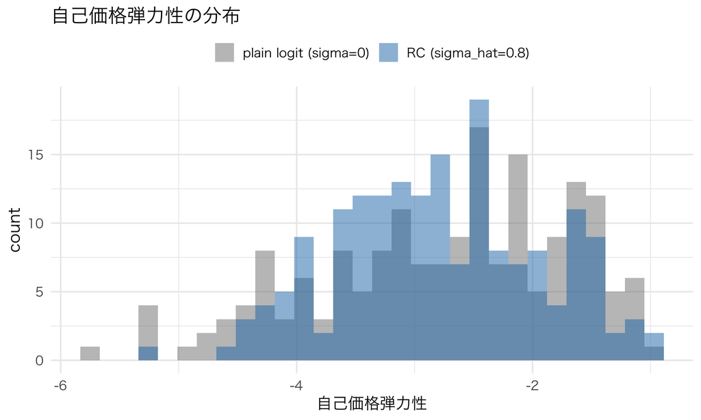

```r
self_elasticities <- function(sigma, abar) {
  fit <- gmm_step(sigma, abar)
  th  <- fit$theta1                                  # c(const, beta_x, coef_price)
  xih <- matrix(fit$xi_hat, T, J, byrow = TRUE)      # t()並び -> byrow=TRUE で戻す
  const <- th[1]; bx <- th[2]; cprice <- th[3]
  eps <- 1e-6
  out <- numeric(0)
  for (t in 1:T) {
    delta_of_p <- function(pv) const + bx * x[t, ] + cprice * pv + xih[t, ]
    p0 <- price[t, ]
    s0 <- shares_from_delta(delta_of_p(p0), p0, abar, sigma, nu_p)
    for (j in 1:J) {
      pj <- p0; pj[j] <- pj[j] + eps
      s1 <- shares_from_delta(delta_of_p(pj), pj, abar, sigma, nu_p)
      out <- c(out, (s1[j] - s0[j]) / eps * p0[j] / s0[j])
    }
  }
  out
}

e_plain <- self_elasticities(0.0, abar_true)
e_hat   <- self_elasticities(0.8, abar_true)

df_e <- data.frame(
  elasticity = c(e_plain, e_hat),
  model = rep(c("plain logit (sigma=0)", "RC (sigma_hat=0.8)"),
              c(length(e_plain), length(e_hat)))
)
ggplot(df_e, aes(elasticity, fill = model)) +
  geom_histogram(alpha = 0.5, position = "identity", bins = 30) +
  scale_fill_manual(values = c("plain logit (sigma=0)" = "grey50",
                               "RC (sigma_hat=0.8)" = "#1f77b4")) +
  labs(title = "自己価格弾力性の分布", x = "自己価格弾力性", fill = NULL) +
  theme(legend.position = "top")
```

```r
cat("plain: mean", round(mean(e_plain), 3), " median", round(median(e_plain), 3),
    " sd", round(sd(e_plain), 3), "\n")
```

```
plain: mean -2.741  median -2.556  sd 1.059
```

```r
cat("RC   : mean", round(mean(e_hat), 3),   " median", round(median(e_hat), 3),
    " sd", round(sd(e_hat), 3), "\n")
```

```
RC   : mean -2.784  median -2.827  sd 0.862
```

**ノート部分点の基準（問6、10点）**

`delta_of_p` で価格を通じた効果を正しく入れていれば（6点）。$\delta$ を固定して $\mu$ だけ動かし、plain の弾力性がゼロになっている答案は、この核心を外しているので −5点（ただし上の callout の趣旨を書けていれば部分点）。ヒストグラム（2点）・sd を見た解釈（2点）。

## 問7：財1・財2の合併分析

穴埋めの答え：$k\neq j$ のとき `ds_k/dp_j = mean(alpha_i * sij[,k] * sij[,j])`、`Delta <- -(Omega * t(M))`、`p_new <- mc + solve(Delta, s)`。

```r
abar_m  <- 0.5;  sigma_m <- 0.8;  Jm <- 4
nu_m <- rnorm(ns)
xbeta_xi  <- c(3.0, 2.6, 2.9, 2.7)
mc_true_m <- c(1.0, 1.1, 1.2, 0.9)

choice_probs <- function(p) {
  alpha_i <- exp(abar_m + sigma_m * nu_m)
  V <- sweep(-outer(alpha_i, p), 2, xbeta_xi, "+")
  eV <- exp(V)
  eV / (1 + rowSums(eV))
}
agg_shares <- function(p) colMeans(choice_probs(p))

dS_dp <- function(p) {
  alpha_i <- exp(abar_m + sigma_m * nu_m)
  sij <- choice_probs(p)
  M <- matrix(0, Jm, Jm)
  for (j in 1:Jm) for (k in 1:Jm) {
    if (k == j) M[k, j] <- mean(-alpha_i * sij[, j] * (1 - sij[, j]))
    else        M[k, j] <- mean(alpha_i * sij[, k] * sij[, j])
  }
  M   # 要素[k,j] = ds_k/dp_j
}

owner_matrix <- function(groups) outer(groups, groups, function(a, b) as.numeric(a == b))

markup_pieces <- function(p, groups) {
  M <- dS_dp(p)
  Omega <- owner_matrix(groups)
  Delta <- -(Omega * t(M))                    # [j,k] = -Omega[j,k]*ds_k/dp_j
  list(Delta = Delta, s = agg_shares(p))
}

solve_equilibrium <- function(mc, groups, p_init, tol = 1e-11, maxit = 2000) {
  p <- p_init
  for (it in 1:maxit) {
    mp <- markup_pieces(p, groups)
    p_new <- mc + solve(mp$Delta, mp$s)
    if (max(abs(p_new - p)) < tol) return(list(p = p_new, iters = it, ok = TRUE))
    p <- p_new
  }
  list(p = p, iters = maxit, ok = FALSE)
}

# 合併前均衡 → mc 逆算 → 合併後均衡
groups_pre  <- c(1, 2, 3, 4)
groups_post <- c(1, 1, 3, 4)

eq_pre <- solve_equilibrium(mc_true_m, groups_pre, p_init = mc_true_m * 1.5)
p0 <- eq_pre$p; s0 <- agg_shares(p0)
cat("合併前均衡の収束:", eq_pre$ok, " 反復:", eq_pre$iters, "\n")
```

```
合併前均衡の収束: TRUE  反復: 17
```

```r
mp0 <- markup_pieces(p0, groups_pre)
mc_implied <- p0 - solve(mp0$Delta, mp0$s)
cat("mc 逆算の最大誤差:", max(abs(mc_implied - mc_true_m)), "\n")
```

```
mc 逆算の最大誤差: 4.520828e-13
```

```r
eq_post <- solve_equilibrium(mc_implied, groups_post, p_init = p0)
p1 <- eq_post$p; s1 <- agg_shares(p1)
cat("合併後均衡の収束:", eq_post$ok, " 反復:", eq_post$iters, "\n")
```

```
合併後均衡の収束: TRUE  反復: 23
```

```r
M0 <- dS_dp(p0)
diversion <- function(j, k) -M0[k, j] / M0[j, j]

merger_tbl <- data.frame(
  product    = paste0("財", 1:4),
  merging    = c("○", "○", "", ""),
  price_pre  = round(p0, 3),
  price_post = round(p1, 3),
  pct_change = round((p1 - p0) / p0 * 100, 2),
  share_pre  = round(s0, 3),
  share_post = round(s1, 3)
)
kable(merger_tbl, caption = "合併の効果（財1・財2の合併）")
```

合併の効果（財1・財2の合併）

| product | merging | price_pre | price_post | pct_change | share_pre | share_post |
| --- | --- | --- | --- | --- | --- | --- |
| 財1 | ○ | 2.049 | 2.254 | 9.98 | 0.190 | 0.166 |
| 財2 | ○ | 2.066 | 2.407 | 16.50 | 0.125 | 0.094 |
| 財3 |  | 2.241 | 2.257 | 0.73 | 0.137 | 0.150 |
| 財4 |  | 1.869 | 1.896 | 1.42 | 0.176 | 0.189 |

```r
cat("D(財1->財2):", round(diversion(1, 2), 3),
    " D(財2->財1):", round(diversion(2, 1), 3), "\n")
```

```
D(財1->財2): 0.176  D(財2->財1): 0.247
```

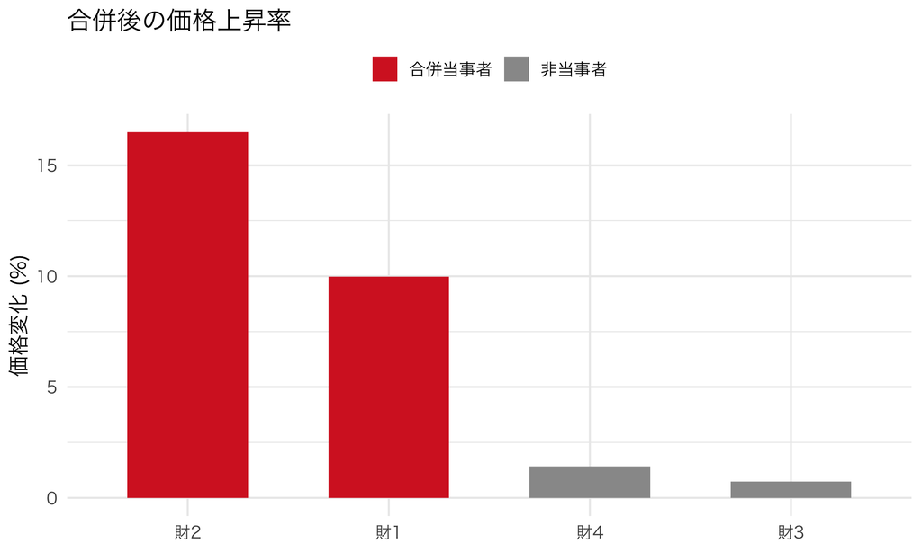

合併による価格上昇率。当事者が大きく上がる（単独効果）。

```r
df_m <- data.frame(product = paste0("財", 1:4),
                   pct = (p1 - p0) / p0 * 100,
                   merging = c("合併当事者", "合併当事者", "非当事者", "非当事者"))
ggplot(df_m, aes(reorder(product, -pct), pct, fill = merging)) +
  geom_col(width = 0.6) +
  scale_fill_manual(values = c("合併当事者" = "#d62728", "非当事者" = "grey60")) +
  labs(title = "合併後の価格上昇率", x = NULL, y = "価格変化 (%)", fill = NULL) +
  theme(legend.position = "top")
```

UPP と消費者余剰も出しておく（審査官パラグラフの材料）。

```r
# UPP（財1、効率化ゼロ）
upp1 <- diversion(1, 2) * (p0[2] - mc_implied[2])
cat("UPP(財1, 効率化なし):", round(upp1, 4),
    " （合併前価格の", round(upp1 / p0[1] * 100, 1), "%）\n")
```

```
UPP(財1, 効率化なし): 0.1702  （合併前価格の 8.3 %）
```

```r
# 消費者余剰（logsum, 1人あたり）
cs_logsum <- function(p) {
  alpha_i <- exp(abar_m + sigma_m * nu_m)
  V <- sweep(-outer(alpha_i, p), 2, xbeta_xi, "+")
  inclusive <- log(1 + rowSums(exp(V)))
  mean(inclusive / alpha_i)
}
cs0 <- cs_logsum(p0); cs1 <- cs_logsum(p1)
cat("消費者余剰（1人あたり）: 前", round(cs0, 4), " 後", round(cs1, 4),
    " 変化", round(cs1 - cs0, 4), "\n")
```

```
消費者余剰（1人あたり）: 前 1.998  後 1.9176  変化 -0.0804
```

UPP は財1の合併前価格のおよそ 8% に相当し、正（値上げ圧力あり）。消費者余剰は合併で減少する。

**ノート部分点の基準（問7、15点）**

`dS_dp` の非対角項（4点）・`Delta` の転置（4点）・固定点反復（4点）が正しく、mc 逆算が真値と一致すれば満点。価格上昇率と diversion の表（3点）。**mc 逆算が真値とズレている**答案は、`t(M)` 忘れか非対角項の符号ミスがほぼ確実なので、そこを指摘。

**警告よくあるバグ集（この課題の総まとめ）**

1. **log の中身がゼロ／負**（問4）：`s_pred` が潰れて `-Inf`。初期値を Berry 反転から、$\sigma$ を大きくしすぎない。
2. **縮小写像の発散**（問4）：更新式の符号ミス（`+` と `-` の取り違え）や `outer` の符号ミス。真値で観測シェアを再現できるかで検知。
3. **delta と X の並び順ズレ**（問5）：`as.vector(t(...))` の `t()` 忘れ。$\sigma$ の谷が消える。
4. **$\delta$ を固定して弾力性を計算**（問6）：価格を通じた $\delta$ の効果を落とし、plain の弾力性がゼロになる。`delta_of_p` で作り直す。
5. **所有行列の書き換えミス**（問7）：`groups` の合併相手を間違える、または `Delta <- -(Omega * t(M))` の `t()` 忘れ。mc 逆算が真値と一致するかで検知。

**ノート部分点の基準（問8、10点）**

数値（価格上昇率・diversion のいずれか）を根拠に引いて承認可否を論じていれば（6点）。「判断が変わる条件」（効率化・参入・代替性の低さ等）に1つ以上触れていれば（4点）。数値を一切引かず定性的な作文だけの場合は −5点。

**重要この課題で身につけたこと**

- ミニBLP の三層（縮小写像 → IV → GMM）を、穴埋めではなく**自分で組めた**。真値 $\sigma=0.8$ を回収できた。
- 異質性を無視すると弾力性の分布を取り違えること、それが合併分析の入力を狂わせることを、数値で確認した。
- Bertrand-Nash の FOC から限界費用を逆算し、所有行列を書き換えて合併後均衡を解き、価格上昇・diversion・UPP・消費者余剰を出せた。
- これらの数字を根拠に、審査官として合併の可否を論じた。第5回のゲスト講義で、実際の審査ではこれがどう使われるかを聞く。